# milestone2_(1)

Name: Zhihe Tu

Project title: Milestone 2

[link to my Github webpage](https://ayudrea.github.io/)

Project description: I picked two datasets that reflects incidents of crime in the City of Los Angeles that dates from 2010 to 2023. I am interested in how is the picture of the crime like in the recent years in a modern big city, and I think it may help to improve the life for people in general to live in modern cities. I will look at the violent trends in Los Angeles first. I will look at the percentage of the genders of the victims after that. I will look at the age distributions next. Now I have a picture about the crimes in Los Angeles. Since the crime types such as criminal homicide have a huge impact on people’s life, I would like to build a model that can predict crime types based on some features. I will use random forest classifier method for the model since it is good at predicting classifications for many attributes. I will choose certain attributes such as area name, victim age and victim sex as my features, ignoring the features such as date report, area etc. since they may not relevant or redundant to my model.

The link for the dataset is: [the link to dataset from 2020 to 2023](https://www.kaggle.com/datasets/susant4learning/crime-in-los-angeles-data-from-2020-to-present) and [the link to dataset from 2010 to 2019](https://www.kaggle.com/datasets/sumaiaparveenshupti/los-angeles-crime-data-20102020)

Resources/Links

There is one year crime statistics report for Los Angeles in 2023, which is released from Los Angeles Police Department(LAPD). The report shows the trend of violent crimes, homeicides and other important statics.It shows that the citywide property crimes statistics has increased by 3.5%. The report helps me to understand crime types such as criminal homicides are important areas for preventing crimes. Therefore, I chose crime types as my predicted value. Here is [the link to the report](https://mayor.lacity.gov/news/lapd-releases-end-year-crime-statistics-city-los-angeles-2023).

The data life circle: Data collection

```python
import matplotlib.pyplot as plt
import numpy as np
import pandas as pd
from google.colab import drive
drive.mount('/content/drive')
data_2010_2019 = pd.read_csv('/content/drive/MyDrive/data science1/Crime_Data_from_2010_to_2019.csv')
data_2020_2023 = pd.read_csv('/content/drive/MyDrive/data science1/Crime_Data_from_2020_to_Present.csv')
```

We are going to look at violent trends in Los Angeles first.

The data life circle: Data processing and EDA

```python
import seaborn as sns
import matplotlib.pyplot as plt
# Combine tw datasets
data_combined = pd.concat([data_2010_2019, data_2020_2023])
# Define violent crime descriptions
violent_crimes = [
    'BATTERY - SIMPLE ASSAULT',
    'RAPE, FORCIBLE',
    'ASSAULT WITH DEADLY WEAPON, AGGRAVATED ASSAULT',
    'ROBBERY',
    'INTIMATE PARTNER - SIMPLE ASSAULT',
    'CRIMINAL THREATS - NO WEAPON DISPLAYED',
    'BRANDISH WEAPON'
]
# Add a new column to indicate if the crime is violent or not
data_combined['Violence_Type'] = data_combined['Crm Cd Desc'].apply(lambda x: 'Violent' if x in violent_crimes else 'Non-Violent')
# Extract year from 'DATE OCC' column with the correct format for the combined dataframe
data_combined['Year'] = pd.to_datetime(data_combined['DATE OCC'], format='%m/%d/%Y %I:%M:%S %p').dt.year
# Violence_Type and Year
cross_tab_year = pd.crosstab(data_combined['Violence_Type'], data_combined['Year'])
# Drop the column for year 2024
cross_tab_year = cross_tab_year.drop(columns=[2024])
print(cross_tab_year)
```

```
Year             2010    2011    2012    2013    2014    2015    2016    2017  \
Violence_Type
Non-Violent    151993  146076  148192  142714  142512  159130  166661  169842
Violent         57182   54629   53308   49882   52959   56339   58749   61178

Year             2018    2019    2020    2021    2022    2023
Violence_Type
Non-Violent    167898  158280  145972  154046  175893  172842
Violent         60926   59139   53777   55714   59184   59135
```

We are going to look at the female and male percentage of the victims next.

```python
# Filter the DataFrame for female victims
female_victims = data_combined[data_combined['Vict Sex'] == 'F']
# Calculate the percentage of female victims
total_victims = len(data_combined)
total_female_victims = len(female_victims)
percentage_female_victims = (total_female_victims / total_victims) * 100
print(f"Percentage of female victims: {percentage_female_victims:.2f}%")
percentage_male_victims = 100 - percentage_female_victims
print(f"Percentage of male victims: {percentage_male_victims:.2f}%")
```

```
Percentage of female victims: 40.19%
Percentage of male victims: 59.81%
```

We will look at ages distributions now.

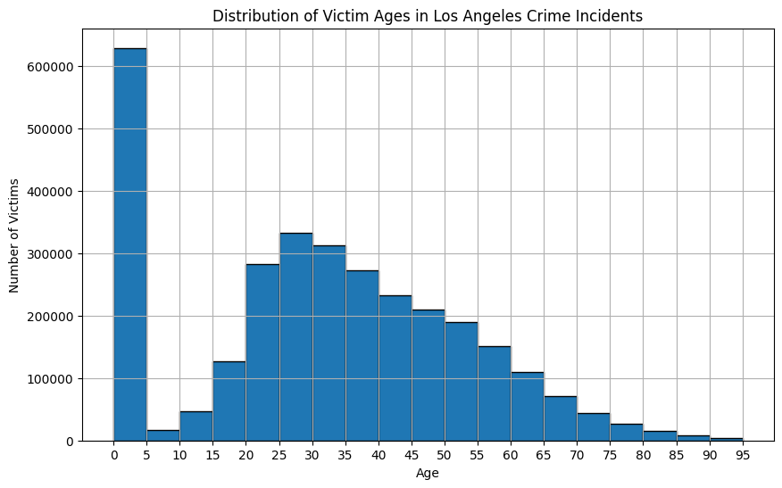

```python
# Plot the histogram for victim ages
plt.figure(figsize=(10, 6))
plt.hist(data_combined['Vict Age'].dropna(), bins=range(0, 100, 5), edgecolor='black')
plt.title('Distribution of Victim Ages in Los Angeles Crime Incidents')
plt.xlabel('Age')
plt.ylabel('Number of Victims')
plt.xticks(range(0, 100, 5))
plt.grid(True)
plt.show()
```

The data life circle: Model

Now I have a picture about the crimes in Los Angeles. As we can see from the first table above, some crimes are violent, some are not. A certain number of crime types such as rape can have huge impact on people’s life. Therefore, I would like to build a model that can predict crime types based on some features. I will use random forest classifier method for the model since it is good at predicting classifications for many attributes.I will use some atrributes such as area name, victim age and victim sex as my features, ignoring the features such as date report, area etc. since they may not relevant or redundant to my model.

```python
import pandas as pd
import numpy as np
import matplotlib.pyplot as plt
from sklearn.model_selection import train_test_split
from sklearn.ensemble import RandomForestClassifier
from sklearn.preprocessing import LabelEncoder
from sklearn.metrics import accuracy_score, precision_score, recall_score, f1_score, classification_report
import seaborn as sns

# Sample a subset
data_sample = data_combined.sample(frac=0.1)
df = data_sample.copy()

# Handle missing values
df['Vict Age'] = df['Vict Age'].fillna(df['Vict Age'].median())
df['Vict Sex'] = df['Vict Sex'].fillna(df['Vict Sex'].mode()[0])
df['Vict Descent'] = df['Vict Descent'].fillna(df['Vict Descent'].mode()[0])
df['Premis Desc'] = df['Premis Desc'].fillna(df['Premis Desc'].mode()[0])
df['Weapon Desc'] = df['Weapon Desc'].fillna(df['Weapon Desc'].mode()[0])
df['AREA NAME'] = df['AREA NAME'].fillna(df['AREA NAME'].mode()[0])
df['Crm Cd Desc'] = df['Crm Cd Desc'].fillna(df['Crm Cd Desc'].mode()[0])
df['Rpt Dist No'] = df['Rpt Dist No'].fillna(df['Rpt Dist No'].mode()[0])
df['Part 1-2'] = df['Part 1-2'].fillna(df['Part 1-2'].mode()[0])
df['Crm Cd'] = df['Crm Cd'].fillna(df['Crm Cd'].mode()[0])

# Encode categorical variables
label_encoder = LabelEncoder()
df['AREA NAME'] = label_encoder.fit_transform(df['AREA NAME'])
df['Crm Cd Desc'] = label_encoder.fit_transform(df['Crm Cd Desc'])
df['Vict Sex'] = label_encoder.fit_transform(df['Vict Sex'])
df['Vict Descent'] = label_encoder.fit_transform(df['Vict Descent'])
df['Premis Desc'] = label_encoder.fit_transform(df['Premis Desc'])
df['Weapon Desc'] = label_encoder.fit_transform(df['Weapon Desc'])

# Splitting the data into features and target
X = df[['TIME OCC', 'AREA NAME', 'Rpt Dist No', 'Part 1-2', 'Crm Cd', 'Vict Age', 'Vict Sex', 'Vict Descent', 'Premis Desc', 'Weapon Desc']]
y = df['Crm Cd Desc']

# Split the data into training and testing sets
X_train, X_test, y_train, y_test = train_test_split(X, y, test_size=0.3, random_state=42)

# Use Random Forest Classifier for the model
model = RandomForestClassifier(n_estimators=100, random_state=42)
model.fit(X_train, y_train)

# Model Evaluation
y_pred = model.predict(X_test)
accuracy = accuracy_score(y_test, y_pred)
precision = precision_score(y_test, y_pred, average='weighted', zero_division=0)
recall = recall_score(y_test, y_pred, average='weighted', zero_division=0)
f1 = f1_score(y_test, y_pred, average='weighted', zero_division=0)

# Print out the results
print(f'Accuracy: {accuracy:.2f}')
print(f'Precision: {precision:.2f}')
print(f'Recall: {recall:.2f}')
print(f'F1 Score: {f1:.2f}')
```

```
Accuracy: 0.98
Precision: 0.98
Recall: 0.98
F1 Score: 0.98
```

The data life circle: Inside and policy decision